# Multiple Regression on Social Media Data

#### **Accuracy**

```r
summary(fit_1)$r.squared
```

```
## [1] 0.4570374
```

**Inference:**

- R-squared range from 0 to 1.
- A value of 0.45 indicates that the model explains partial variability in the target variable, suggesting that the independent variables have limited predictive power.

#### **As observed the model may not have been performing well. Therefore, let’s conduct PCA and carry out Multiple Regression on the PCs to check if that provides any improvement**

```r
social_media_num <- social_media_reg[, c("Instagram_Hours", "LinkedIn_Hours",   "Snapchat_Hours", "Twitter_Hours",  "Whatsapp_Wechat_hours", "Reddit_hours",    "Youtube_hours",    "OTT_hours", "Mood_Productivity_num")]

social_media_num_pca <- social_media_num[, c("Instagram_Hours", "LinkedIn_Hours",   "Snapchat_Hours", "Twitter_Hours",  "Whatsapp_Wechat_hours", "Reddit_hours",    "Youtube_hours",    "OTT_hours")]

social_media_pca <- prcomp(social_media_num_pca, scale. = TRUE)

social_media_pca
```

```
## Standard deviations (1, .., p=8):
## [1] 1.6462847 1.3946849 1.0175878 0.9265274 0.8013579 0.6579756 0.5037044
## [8] 0.3490535
##
## Rotation (n x k) = (8 x 8):
##                               PC1         PC2          PC3         PC4
## Instagram_Hours       -0.50156955 -0.19881023  0.261699750  0.03089734
## LinkedIn_Hours        -0.36188622  0.16322745 -0.411953246 -0.44873244
## Snapchat_Hours        -0.50008890  0.04575341  0.230833436  0.12703404
## Twitter_Hours          0.01339412 -0.65106837  0.006432687 -0.29702284
## Whatsapp_Wechat_hours -0.30915077  0.40706854  0.197920894  0.39402099
## Reddit_hours          -0.02588209 -0.28626122 -0.631170320  0.68599708
## Youtube_hours         -0.32044312  0.23691295 -0.517375840 -0.25449166
## OTT_hours             -0.41020747 -0.45174094  0.057060468  0.05209419
##                               PC5         PC6           PC7         PC8
## Instagram_Hours       -0.07249373  0.17748039 -0.7745192714  0.05316331
## LinkedIn_Hours        -0.44237354 -0.52316529 -0.0435360678 -0.00610143
## Snapchat_Hours        -0.41267442  0.38095293  0.4977970211 -0.33936530
## Twitter_Hours          0.24412333 -0.16547573  0.0446633330 -0.63142173
## Whatsapp_Wechat_hours  0.43062761 -0.51341475 -0.0008341252 -0.30864261
## Reddit_hours          -0.17163963 -0.00905846 -0.0888596979 -0.10477787
## Youtube_hours          0.53693159  0.46658224  0.0149463110 -0.05026722
## OTT_hours              0.25682310 -0.20227628  0.3745766779  0.61197122
```

```r
summary(social_media_pca)
```

```
## Importance of components:
##                           PC1    PC2    PC3    PC4     PC5     PC6     PC7
## Standard deviation     1.6463 1.3947 1.0176 0.9265 0.80136 0.65798 0.50370
## Proportion of Variance 0.3388 0.2431 0.1294 0.1073 0.08027 0.05412 0.03171
## Cumulative Proportion  0.3388 0.5819 0.7114 0.8187 0.89894 0.95306 0.98477
##                            PC8
## Standard deviation     0.34905
## Proportion of Variance 0.01523
## Cumulative Proportion  1.00000
```

**Scree Plot**

**To further understand the ideal number of PCs, we can carry out the Scree Plot**

```r
(eigen_social_media <- social_media_pca$sdev^2)
```

```
## [1] 2.7102533 1.9451459 1.0354850 0.8584530 0.6421744 0.4329318 0.2537181
## [8] 0.1218383
```

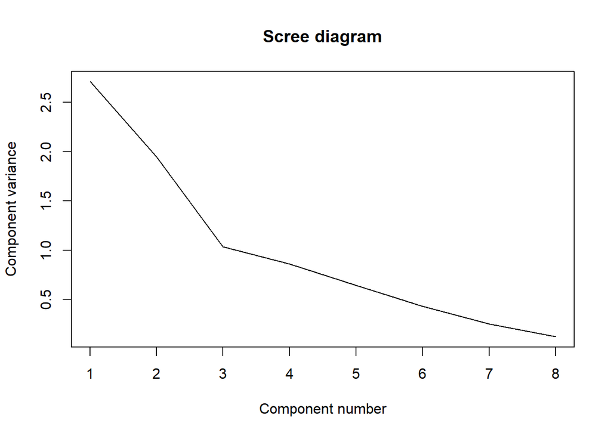

```r
names(eigen_social_media) <- paste("PC",1:8,sep="")

plot(eigen_social_media, xlab = "Component number", ylab = "Component variance", type = "l", main = "Scree diagram")
```

**Inference**:

- Based on the observed Scree plots, **3 can be chosen as the ideal number of Principal Components**

#### **Multiple Regression using 3 PCs**

```r
PC1 <- social_media_pca$x[, 1]
PC2 <- social_media_pca$x[, 2]
PC3 <- social_media_pca$x[, 3]

# Create a new dataset with selected principal components
pc_data <- data.frame(PC1, PC2, PC3)

#Combining Target Variable to pc_data
pc_data$mood_prod_num <- social_media_reg$Mood_Productivity_num
```

```r
pc_data
```

```
##                  PC1         PC2         PC3 mood_prod_num
## masinl  -1.698472811 -5.06618769 -0.34941445             1
## peace   -0.922266283  0.69686308 -0.15278279             1
## Patty    0.008995682  0.91799850 -0.10215824             1
## Bunny    0.136388352  0.31380912  0.12498266             1
## tl868    1.794741167 -0.28021688 -0.58973548             1
## drphy   -1.022334916  1.79187038 -1.64589386             1
## trave    0.681148416  0.65875219 -0.12248089             1
## 19!@s   -0.826939353  0.51920856  0.91611503             1
## yh2020  -2.237981863  0.74232443 -0.64664158             1
## ds2134   2.342127061  0.18022649 -0.06557973             0
## ki567    1.719310569 -1.40275257  0.56120125             1
## ak2001   1.248555946 -1.26012105  0.14839745             1
## Harvey   1.064860135 -0.20692482  0.99398993             1
## hahah    0.603133416 -0.39003895  0.28633368             1
## AKIRA    0.026089656 -0.72060990 -2.71315263             1
## vp1234  -0.224005336  0.60726890 -0.95428963             1
## sss32   -0.260755007  0.67235060  0.92487843             1
## MVA37@S  0.364124195 -0.01993177  1.29310533             1
## 2134     0.031060901  1.22322519 -0.59695934             1
## 15801   -4.898113653  0.26348888  1.45400099             1
## Baiqi    2.070333726  0.75939731  1.23608389             1
```

```r
fit_pc <- lm(mood_prod_num~PC1+PC2+PC3, data=pc_data)

summary(fit_pc)
```

```
##
## Call:
## lm(formula = mood_prod_num ~ PC1 + PC2 + PC3, data = pc_data)
##
## Residuals:
##      Min       1Q   Median       3Q      Max
## -0.85014  0.01148  0.05400  0.08049  0.13668
##
## Coefficients:
##              Estimate Std. Error t value Pr(>|t|)
## (Intercept)  0.952381   0.048799  19.516 4.46e-13 ***
## PC1         -0.043209   0.030374  -1.423    0.173
## PC2         -0.004633   0.035853  -0.129    0.899
## PC3          0.003167   0.049140   0.064    0.949
## ---
## Signif. codes:  0 '***' 0.001 '**' 0.01 '*' 0.05 '.' 0.1 ' ' 1
##
## Residual standard error: 0.2236 on 17 degrees of freedom
## Multiple R-squared:  0.1074, Adjusted R-squared:  -0.05017
## F-statistic: 0.6815 on 3 and 17 DF,  p-value: 0.5754
```

**Inference:**

- Here, all the PCs can be seen to have a high P-value (>0.05).
- The next best method to deal with this could be to carry out **Factor Analysis** to check for a better model.

#### **Factor Analysis and Multiple Regression on FCs**

**Scree Plot – To check for the ideal number of factors**

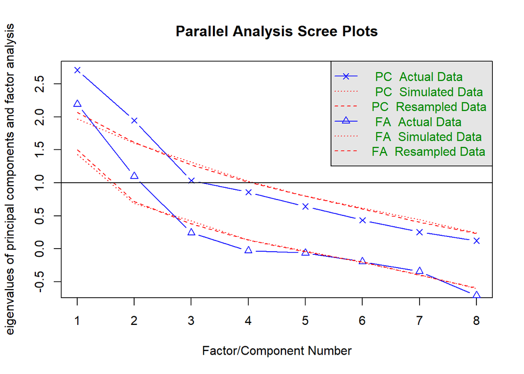

```
## Parallel analysis suggests that the number of factors =  2  and the number of components =  2
```

```r
fa.parallel(social_media_num_pca)
```

**Inference**:

- Following the FA Actual Data, we can interpret as **2 to be the ideal number of factors**.

**Factor Model**

```r
fit.pc <- principal(social_media_num_pca, nfactors=2, rotate="varimax")

round(fit.pc$values, 3)
```

```
## [1] 2.710 1.945 1.035 0.858 0.642 0.433 0.254 0.122
```

```r
fit.pc$loadings
```

```
##
## Loadings:
##                       RC1    RC2
## Instagram_Hours        0.741  0.457
## LinkedIn_Hours         0.632
## Snapchat_Hours         0.816  0.125
## Twitter_Hours         -0.227  0.879
## Whatsapp_Wechat_hours  0.624 -0.438
## Reddit_hours                  0.399
## Youtube_hours          0.589 -0.202
## OTT_hours              0.515  0.767
##
##                  RC1   RC2
## SS loadings    2.671 1.984
## Proportion Var 0.334 0.248
## Cumulative Var 0.334 0.582
```

#### **Multiple Regression using 2 RCs**

```r
loadings <- fit.pc$scores[, c("RC1", "RC2")]
loadings_df <- as.data.frame(loadings)
loadings_df <- round(loadings_df, 3)
```

```r
loadings_df$mood_prod_num <- social_media_reg$Mood_Productivity_num
```

```r
fit_rc <- lm(mood_prod_num~RC1+RC2, data=loadings_df)

summary(fit_rc)
```

```
##
## Call:
## lm(formula = mood_prod_num ~ RC1 + RC2, data = loadings_df)
##
## Residuals:
##      Min       1Q   Median       3Q      Max
## -0.85041  0.01175  0.05225  0.08011  0.14053
##
## Coefficients:
##             Estimate Std. Error t value Pr(>|t|)
## (Intercept)  0.95238    0.04743  20.079    9e-14 ***
## RC1          0.06780    0.04860   1.395     0.18
## RC2          0.02241    0.04860   0.461     0.65
## ---
## Signif. codes:  0 '***' 0.001 '**' 0.01 '*' 0.05 '.' 0.1 ' ' 1
##
## Residual standard error: 0.2174 on 18 degrees of freedom
## Multiple R-squared:  0.1071, Adjusted R-squared:  0.00786
## F-statistic: 1.079 on 2 and 18 DF,  p-value: 0.3609
```

**Inference:**

- Here, all the RCs can be seen to have a high P-value (>0.05) indicating that this may not be the right course of action.

#### **Summary**

- The analysis has helped us identify how multiple regression worked a little better once we got rid of the ‘Snpachat’ column. It gave us a an r-square value of 0.457.
- Furthermore, once resorted to Principal Component Analysis and Factor Analysis with expectations to achieve better results - similar inference of poor performance can be drawn out.